# Listener Comfort Scale Preliminary Analysis

Micah E. Hirsch

3/7/2022

This is the preliminary analysis rmd file for the listener comfort scale. This analysis is primarily a descriptive analysis to check for trends in the data. Plots/data visualizations will also be generated. This work is part of Peyton Davis’ undergraduate Honors in the Major thesis project at Florida State University.

# Load Packages

```r
library(rio)
library(tidyverse)
library(furniture)
library(corrr)
library(ggpubr)
```

# Loading the dataset

This is the clean and deidentified version of the dataset. Code showing how this data was prepped can also be found in the following GitHub Repository: https://github.com/micah-hirsch/Preliminary-Listener-Comfort-Scale-Analysis

```r
LCscale_data <- rio::import("LCscale_CleanData.csv")
```

# Participant Demographics

These are the demographic information for the participants in our pilot study (age, gender, race, ethnicity, and whether participants were familiar with communication disorders (Familiar_CSD))

```r
Listeners <- LCscale_data %>%
  furniture::table1(Age, Gender, Race, Ethnicity, Familiar_CSD)
```

```r
Listeners
```

```
##
## ────────────────────────────────────────────
##                           Mean/Count (SD/%)
##                           n = 10
##  Age
##                           20.5 (1.0)
##  Gender
##     Man                   2 (20%)
##     Woman                 8 (80%)
##  Race
##     White/Caucasian       10 (100%)
##  Ethnicity
##     Hispanic/Latinx/e     2 (20%)
##     Not Hispanic/Latinx/e 8 (80%)
##  Familiar_CSD
##     No                    4 (40%)
##     Yes                   6 (60%)
## ────────────────────────────────────────────
```

# Descriptive Statistics

The descriptive statistics (means and standard deviations) for the average overall scores for the listener comfort scale (LC_Score), Schölderle et al. (2019) overall attitudes scale score (S_Score), and the three subscores from the Schölderle et al. (2019) attitudes scale: Cognition and Language (S_Cogn), Personality (S_personality), and emotional reaction (S_emotion). The first output is for all 10 listeners. The second output groups by the speaker (a healthy control (HC) speaker or a speaker with dysarthria) that the listeners heard during the study.

## Means and SD

```r
Descriptives_overall <- LCscale_data %>%
  dplyr::summarize(LC_Score = mean(LC_overallScore), LC_sd = sd(LC_overallScore),
                   S_Score = mean(S_overallScore), S_sd = sd(S_overallScore),
                   S_Cogn = mean(S_cogn_score), S_Cogn_sd = sd(S_cogn_score),
                   S_personality = mean(S_personality_score), S_personality_sd = sd(S_personality_score),
                   S_emotion = mean(S_emotion_score), S_emotion_sd = sd(S_emotion_score))

Descriptives_overall
```

```
##   LC_Score     LC_sd S_Score      S_sd S_Cogn S_Cogn_sd S_personality
## 1  4.71875 0.7004773   4.265 0.4749561  4.275 0.6313566      4.283333
##   S_personality_sd S_emotion S_emotion_sd
## 1        0.3518031  4.233333    0.9067647
```

```r
Descriptives_bySpeaker <- LCscale_data %>%
  dplyr::group_by(Speaker) %>%
  dplyr::summarize(LC_Score = mean(LC_overallScore), LC_sd = sd(LC_overallScore),
                   S_Score = mean(S_overallScore), S_sd = sd(S_overallScore),
                   S_Cogn = mean(S_cogn_score), S_Cogn_sd = sd(S_cogn_score),
                   S_personality = mean(S_personality_score), S_personality_sd = sd(S_personality_score),
                   S_emotion = mean(S_emotion_score), S_emotion_sd = sd(S_emotion_score))

Descriptives_bySpeaker
```

```
## # A tibble: 2 × 11
##   Speaker    LC_Score LC_sd S_Score  S_sd S_Cogn S_Cogn_sd S_personality
##   <chr>         <dbl> <dbl>   <dbl> <dbl>  <dbl>     <dbl>         <dbl>
## 1 Dysarthria     4.84 0.570    4.46 0.509   4.32     0.748          4.43
## 2 HC             4.6  0.862    4.07 0.391   4.22     0.576          4.13
## # … with 3 more variables: S_personality_sd <dbl>, S_emotion <dbl>,
## #   S_emotion_sd <dbl>
```

```r
rio::export(Descriptives_bySpeaker, "Descriptives_bySpeaker.csv")
```

## Data Vis

Bar charts for the overall average scores for the listener comfort scale and the Schölderle et al. (2019) attitudes scale.

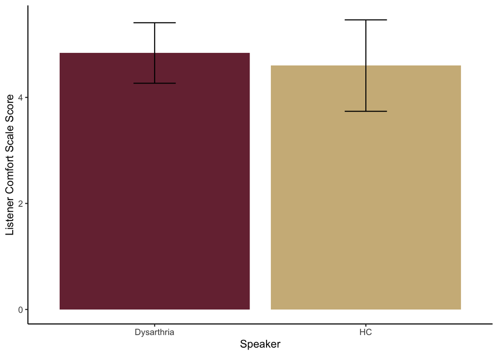

```r
LC_score_plot <- Descriptives_bySpeaker %>%
  ggplot() +
  aes(x = Speaker,
      y = LC_Score,
      fill = Speaker) +
  geom_col(stat = "identity", fill = c("#782F40","#CEB888")) +
  geom_errorbar(aes(ymin = LC_Score-LC_sd, ymax = LC_Score+LC_sd), width = .2) +
  ylab("Listener Comfort Scale Score") +
  theme_classic()
LC_score_plot
```

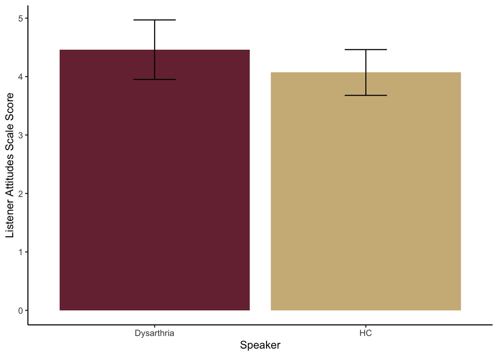

```r
S_score_plot <- Descriptives_bySpeaker %>%
  ggplot() +
  aes(x = Speaker,
      y = S_Score,
      fill = Speaker) +
  geom_col(stat = "identity", fill = c("#782F40","#CEB888")) +
  geom_errorbar(aes(ymin = S_Score-S_sd, ymax = S_Score+S_sd), width = .2) +
  ylab("Listener Attitudes Scale Score") +
  theme_classic()
S_score_plot
```

```r
Score_plots <- ggarrange(LC_score_plot, S_score_plot, common.legend = T, legend = "bottom", labels = c("A", "B"), nrow = 1, ncol = 2)
ggsave("Plots/Score_plots.png", plot = last_plot(), width = 10, height = 5, units = "in", scale = .8)

Scatterplot <- LCscale_data %>%
  ggplot() +
  aes(x = S_overallScore,
      y = LC_overallScore) +
  geom_point() +
  geom_smooth(method = "lm", se = T, color = "#782F40", fill = "light grey") +
  xlab("Attitudes Rating Overall Scale") +
  ylab("Listener Comfort Overall Score") +
  theme_classic()

ggsave("Plots/LC_Scholderle_scatterplot.png", plot = last_plot(), width = 10, height = 10, units = "in", scale = .8)
```

## Correlations

This a correlation matrix between the overall listener comfort score, the overall attitudes scale (Scholderle et al., 2019) score, and the three subscores from the Schölderle et al. (2019) attitudes scale. One of the main things to note is that the correlation between the listener comfort overall score and the Schölderle attitudes overall score is strong and positive (r=.860, p=.001).

```r
CorrMatrix <- LCscale_data %>%
  dplyr::select(!c(ID:S20)) %>%
  correlate()
```

```
##
## Correlation method: 'pearson'
## Missing treated using: 'pairwise.complete.obs'
```

```r
CorrMatrix
```

```
## # A tibble: 5 × 6
##   term              LC_overallScore S_overallScore S_cogn_score S_personality_s…
##   <chr>                       <dbl>          <dbl>        <dbl>            <dbl>
## 1 LC_overallScore            NA              0.860        0.612            0.580
## 2 S_overallScore              0.860         NA            0.714            0.653
## 3 S_cogn_score                0.612          0.714       NA                0.194
## 4 S_personality_sc…           0.580          0.653        0.194           NA
## 5 S_emotion_score             0.709          0.829        0.243            0.573
## # … with 1 more variable: S_emotion_score <dbl>
```

```r
stats::cor.test(LCscale_data$LC_overallScore, LCscale_data$S_overallScore, method = "pearson")
```

```
##
##  Pearson's product-moment correlation
##
## data:  LCscale_data$LC_overallScore and LCscale_data$S_overallScore
## t = 4.7774, df = 8, p-value = 0.001395
## alternative hypothesis: true correlation is not equal to 0
## 95 percent confidence interval:
##  0.5038624 0.9664888
## sample estimates:
##       cor
## 0.8604995
```

## Group Differences

### LC Score

A t-test was used to test the whether the difference in the overall listener comfort scores are different between the participants who listened to the Dysarthria talker and those who listened to the HC talker. There was no significant different (t(8)=-.5137, p=.6213).

```r
# Creating Dysarthria and HC data frames

Dysarthria <- LCscale_data %>%
  dplyr::filter(Speaker == "Dysarthria")

HC <- LCscale_data %>%
  dplyr::filter(Speaker == "HC")

# Assumption Check

## Checking Normality

with(LCscale_data, shapiro.test(LC_overallScore[Speaker == "HC"]))
```

```
##
##  Shapiro-Wilk normality test
##
## data:  LC_overallScore[Speaker == "HC"]
## W = 0.85759, p-value = 0.2197
```

```r
with(LCscale_data, shapiro.test(LC_overallScore[Speaker == "Dysarthria"]))
```

```
##
##  Shapiro-Wilk normality test
##
## data:  LC_overallScore[Speaker == "Dysarthria"]
## W = 0.81643, p-value = 0.1096
```

```r
## Equal Variance Check

res.ftest.LC <- var.test(LC_overallScore ~ Speaker, data = LCscale_data)
res.ftest.LC
```

```
##
##  F test to compare two variances
##
## data:  LC_overallScore by Speaker
## F = 0.43773, num df = 4, denom df = 4, p-value = 0.4433
## alternative hypothesis: true ratio of variances is not equal to 1
## 95 percent confidence interval:
##  0.04557536 4.20418991
## sample estimates:
## ratio of variances
##          0.4377299
```

```r
# Model Results

LC_diff <- t.test(HC$LC_overallScore, Dysarthria$LC_overallScore, var.equal = T)
LC_diff
```

```
##
##  Two Sample t-test
##
## data:  HC$LC_overallScore and Dysarthria$LC_overallScore
## t = -0.5137, df = 8, p-value = 0.6213
## alternative hypothesis: true difference in means is not equal to 0
## 95 percent confidence interval:
##  -1.3036373  0.8286373
## sample estimates:
## mean of x mean of y
##    4.6000    4.8375
```

### Scholderle Overall Score

A t-test was used to test the whether the difference in the overall Schölderle attitdes scale scores are different between the participants who listened to the Dysarthria talker and those who listened to the HC talker. There was no significant different (t(8)=-1.3578, p=.2116).

```r
# Assumption Check

## Checking Normality

with(LCscale_data, shapiro.test(S_overallScore[Speaker == "HC"]))
```

```
##
##  Shapiro-Wilk normality test
##
## data:  S_overallScore[Speaker == "HC"]
## W = 0.84998, p-value = 0.1944
```

```r
with(LCscale_data, shapiro.test(S_overallScore[Speaker == "Dysarthria"]))
```

```
##
##  Shapiro-Wilk normality test
##
## data:  S_overallScore[Speaker == "Dysarthria"]
## W = 0.88428, p-value = 0.3292
```

```r
## Equal Variance Check

res.ftest.S <- var.test(S_overallScore ~ Speaker, data = LCscale_data)
res.ftest.S
```

```
##
##  F test to compare two variances
##
## data:  S_overallScore by Speaker
## F = 1.6917, num df = 4, denom df = 4, p-value = 0.623
## alternative hypothesis: true ratio of variances is not equal to 1
## 95 percent confidence interval:
##   0.1761336 16.2477936
## sample estimates:
## ratio of variances
##            1.69168
```

```r
# Model Results

S_diff <- t.test(HC$S_overallScore, Dysarthria$S_overallScore, var.equal = T)
S_diff
```

```
##
##  Two Sample t-test
##
## data:  HC$S_overallScore and Dysarthria$S_overallScore
## t = -1.3578, df = 8, p-value = 0.2116
## alternative hypothesis: true difference in means is not equal to 0
## 95 percent confidence interval:
##  -1.0523493  0.2723493
## sample estimates:
## mean of x mean of y
##      4.07      4.46
```

### Scholderle Cognition Subscore

A Mann Whitney U test was used to test the whether the difference in the overall Schölderle attitdes scale scores are different between the participants who listened to the Dysarthria talker and those who listened to the HC talker. (assumptions for the t-test were not met) There was no significant different (U=11, p=.8335).

```r
# Assumption Check

## Checking Normality

with(LCscale_data, shapiro.test(S_cogn_score[Speaker == "HC"]))
```

```
##
##  Shapiro-Wilk normality test
##
## data:  S_cogn_score[Speaker == "HC"]
## W = 0.94273, p-value = 0.6853
```

```r
with(LCscale_data, shapiro.test(S_cogn_score[Speaker == "Dysarthria"]))
```

```
##
##  Shapiro-Wilk normality test
##
## data:  S_cogn_score[Speaker == "Dysarthria"]
## W = 0.76292, p-value = 0.03903
```

```r
## Equal Variance Check

res.ftest.Cogn <- var.test(S_cogn_score ~ Speaker, data = LCscale_data)
res.ftest.Cogn
```

```
##
##  F test to compare two variances
##
## data:  S_cogn_score by Speaker
## F = 1.6887, num df = 4, denom df = 4, p-value = 0.6242
## alternative hypothesis: true ratio of variances is not equal to 1
## 95 percent confidence interval:
##   0.1758211 16.2189703
## sample estimates:
## ratio of variances
##           1.688679
```

```r
# Model Results (Mann Whitney U Test)

Cogn_MW <- wilcox.test(S_cogn_score ~ Speaker, data = LCscale_data)
Cogn_MW
```

```
##
##  Wilcoxon rank sum test with continuity correction
##
## data:  S_cogn_score by Speaker
## W = 11, p-value = 0.8335
## alternative hypothesis: true location shift is not equal to 0
```

### Scholderle Personality Subscore

A t-test was used to test the whether the difference in the personality subscore for the Schölderle attitdes scale are different between the participants who listened to the Dysarthria talker and those who listened to the HC talker. There was no significant different (t(8)=-1.423, p=.1925).

```r
# Assumption Check

## Checking Normality

with(LCscale_data, shapiro.test(S_personality_score[Speaker == "HC"]))
```

```
##
##  Shapiro-Wilk normality test
##
## data:  S_personality_score[Speaker == "HC"]
## W = 0.8713, p-value = 0.2717
```

```r
with(LCscale_data, shapiro.test(S_personality_score[Speaker == "Dysarthria"]))
```

```
##
##  Shapiro-Wilk normality test
##
## data:  S_personality_score[Speaker == "Dysarthria"]
## W = 0.86684, p-value = 0.2538
```

```r
## Equal Variance Check

res.ftest.Personality <- var.test(S_personality_score ~ Speaker, data = LCscale_data)
res.ftest.Personality
```

```
##
##  F test to compare two variances
##
## data:  S_personality_score by Speaker
## F = 0.70213, num df = 4, denom df = 4, p-value = 0.7402
## alternative hypothesis: true ratio of variances is not equal to 1
## 95 percent confidence interval:
##  0.0731038 6.7436061
## sample estimates:
## ratio of variances
##          0.7021277
```

```r
# Model Results

Personality_diff <- t.test(HC$S_personality_score, Dysarthria$S_personality_score, var.equal = T)
Personality_diff
```

```
##
##  Two Sample t-test
##
## data:  HC$S_personality_score and Dysarthria$S_personality_score
## t = -1.423, df = 8, p-value = 0.1925
## alternative hypothesis: true difference in means is not equal to 0
## 95 percent confidence interval:
##  -0.7861484  0.1861484
## sample estimates:
## mean of x mean of y
##  4.133333  4.433333
```

### Emotion

A t-test was used to test the whether the difference in the personality subscore for the Schölderle attitdes scale are different between the participants who listened to the Dysarthria talker and those who listened to the HC talker. There was no significant different (t(8)=-1.6493, p=.1377).

```r
# Assumption Check

## Checking Normality

with(LCscale_data, shapiro.test(S_emotion_score[Speaker == "HC"]))
```

```
##
##  Shapiro-Wilk normality test
##
## data:  S_emotion_score[Speaker == "HC"]
## W = 0.93102, p-value = 0.6034
```

```r
with(LCscale_data, shapiro.test(S_emotion_score[Speaker == "Dysarthria"]))
```

```
##
##  Shapiro-Wilk normality test
##
## data:  S_emotion_score[Speaker == "Dysarthria"]
## W = 0.92207, p-value = 0.5434
```

```r
## Equal Variance Check

res.ftest.Emotion <- var.test(S_emotion_score ~ Speaker, data = LCscale_data)
res.ftest.Emotion
```

```
##
##  F test to compare two variances
##
## data:  S_emotion_score by Speaker
## F = 0.26786, num df = 4, denom df = 4, p-value = 0.2301
## alternative hypothesis: true ratio of variances is not equal to 1
## 95 percent confidence interval:
##  0.02788863 2.57264193
## sample estimates:
## ratio of variances
##          0.2678571
```

```r
# Model Results

Emotion_diff <- t.test(HC$S_emotion_score, Dysarthria$S_emotion_score, var.equal = T)
Emotion_diff
```

```
##
##  Two Sample t-test
##
## data:  HC$S_emotion_score and Dysarthria$S_emotion_score
## t = -1.6493, df = 8, p-value = 0.1377
## alternative hypothesis: true difference in means is not equal to 0
## 95 percent confidence interval:
##  -2.0783860  0.3450526
## sample estimates:
## mean of x mean of y
##  3.800000  4.666667
```

# Male and Female Score Comparisons

The two men in our study only rated the healthy control speaker. So this descriptive analysis will only reflect ratings given for the healthy control talker (n=5).

## Descriptives

For the Overall Schölderle Score

Men: mean = 4.03, SD = .60 Women: 4.10, SD = .35

Schölderle mean and SD for subscale scores reported in output below.

```r
# Filtering out the listeners who rated the talker with dysarthria. This way we have a dataset with only the ratings for the HC talker.

HC <- LCscale_data %>%
  dplyr::filter(Speaker == "HC")

# Descriptive Statistics

Descriptives_byGender <- HC %>%
  dplyr::group_by(Speaker, Gender) %>%
  dplyr::summarize(LC_Score = mean(LC_overallScore), LC_sd = sd(LC_overallScore),
                   S_Score = mean(S_overallScore), S_sd = sd(S_overallScore),
                   S_Cogn = mean(S_cogn_score), S_Cogn_sd = sd(S_cogn_score),
                   S_personality = mean(S_personality_score), S_personality_sd = sd(S_personality_score),
                   S_emotion = mean(S_emotion_score), S_emotion_sd = sd(S_emotion_score))
Descriptives_byGender
```

```
## # A tibble: 2 × 12
## # Groups:   Speaker [1]
##   Speaker Gender LC_Score LC_sd S_Score  S_sd S_Cogn S_Cogn_sd S_personality
##   <chr>   <chr>     <dbl> <dbl>   <dbl> <dbl>  <dbl>     <dbl>         <dbl>
## 1 HC      Man        4.53 1.19     4.03 0.601   4.75     0.177          4
## 2 HC      Woman      4.65 0.876    4.1  0.350   3.88     0.433          4.22
## # … with 3 more variables: S_personality_sd <dbl>, S_emotion <dbl>,
## #   S_emotion_sd <dbl>
```

```r
rio::export(Descriptives_byGender, "Descriptives_byGender.csv")
```

# Comparison Based on Familiarity with CSD

Comparing mean and standard deviation of scores for participants familiar with CSD vs. unfamiliar with CSD

## Descriptives

For the Overall Schölderle Score

Dysarthria Talker: Familiar with CSD: mean = 4.17, SD = .19 Not Familiar with CSD: mean = 4.90, SD = .57

HC Talker: Familiar with CSD: mean = 4.35, SD = .10 Not Familiar with CSD: mean = 3.65, SD = .07

Schölderle mean and SD for subscale scores reported in output below.

```r
# Descriptive Statistics

Descriptives_byCSD <- LCscale_data %>%
  dplyr::group_by(Speaker, Familiar_CSD) %>%
  dplyr::summarize(LC_Score = mean(LC_overallScore), LC_sd = sd(LC_overallScore),
                   S_Score = mean(S_overallScore), S_sd = sd(S_overallScore),
                   S_Cogn = mean(S_cogn_score), S_Cogn_sd = sd(S_cogn_score),
                   S_personality = mean(S_personality_score), S_personality_sd = sd(S_personality_score),
                   S_emotion = mean(S_emotion_score), S_emotion_sd = sd(S_emotion_score))
Descriptives_byCSD
```

```
## # A tibble: 4 × 12
## # Groups:   Speaker [2]
##   Speaker    Familiar_CSD LC_Score  LC_sd S_Score   S_sd S_Cogn S_Cogn_sd
##   <chr>      <chr>           <dbl>  <dbl>   <dbl>  <dbl>  <dbl>     <dbl>
## 1 Dysarthria No               5.31 0.707     4.9  0.566    4.94     0.972
## 2 Dysarthria Yes              4.52 0.157     4.17 0.189    3.92     0.144
## 3 HC         No               3.72 0.0442    3.65 0.0707   4        0.884
## 4 HC         Yes              5.19 0.438     4.35 0.100    4.38     0.433
## # … with 4 more variables: S_personality <dbl>, S_personality_sd <dbl>,
## #   S_emotion <dbl>, S_emotion_sd <dbl>
```

```r
rio::export(Descriptives_byCSD, "Descriptives_byCSD.csv")
```